# second week: Introduction to R and Rstudio

Mobile Data

Niloofar Tarighat-94101448

2018-02-19 23:57:49

# تمرین سری دوم: تلفن همراه شناسی!

> با استفاده از داده های گوشی های همراه به سوالات زیر پاسخ دهید. برای رسم نمودار از پکیج ggplot2 استفاده کنید.

۱. کدام شرکت بیشترین تعداد گوشی را تولید کرده است؟ نمودار ستونی ۲۰ شرکت برتر بر حسب تعداد گوشی تولید کرده را رسم کنید.

ابتدا گوشی ها را بر حسب کمپانی آنها گروه بندی کرده سپس در هر گروه گوشی ها را برحسب تعداد مرتب میکنیم . ۲۰ تای اول را انتخاب میکنیم و نمودار فراوانی این ۲۰ گوشی پرتولید را رسم میکنیم

```r
mobile %>%
  group_by(company) %>%
  summarise(count=n()) %>% arrange(desc(count))->datacount


cat("Biggest Company in manufacturing : ", datacount$company[which.max(datacount$count)])
```

```
## Biggest Company in manufacturing :  Samsung
```

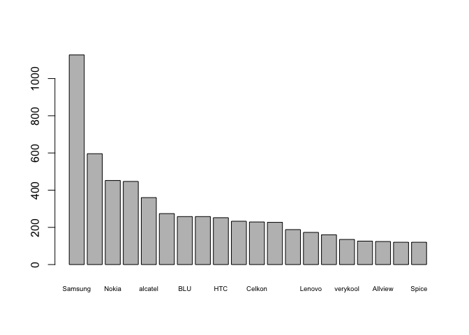

```r
mobile2=datacount[1:20,]
#method2
barplot(mobile2$count,names.arg = mobile2$company,cex.names = 0.6)
```

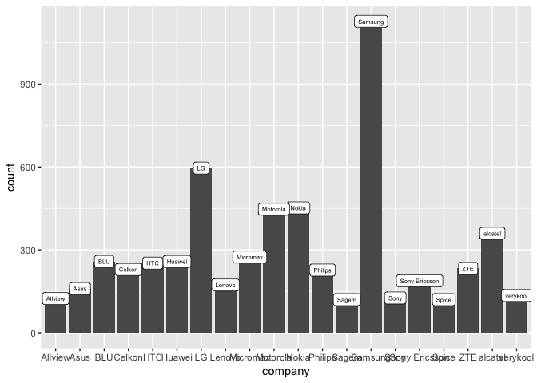

```r
#method2
p = ggplot(mobile2, aes(x=company,y=count))
p + geom_bar(stat ="identity",aes(x=company,y=count))+geom_label(aes(label=company),size=2)
```

۲. نمودار زمانی طول عرض ضخامت و کیفیت دوربین گوشی ها را بکشید و به نمودار هر یک مدل خطی اضافه کنید.

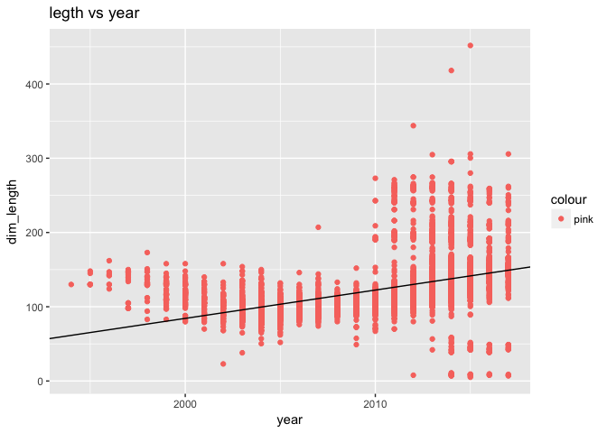

```r
p = ggplot(data = mobile, aes(x = year, y = dim_length,color = "pink"))
coef = coef(lm(dim_length ~ year, data = mobile))
p + geom_point() + geom_abline(intercept = coef[1], slope = coef[2])+
  ggtitle("legth vs year")
```

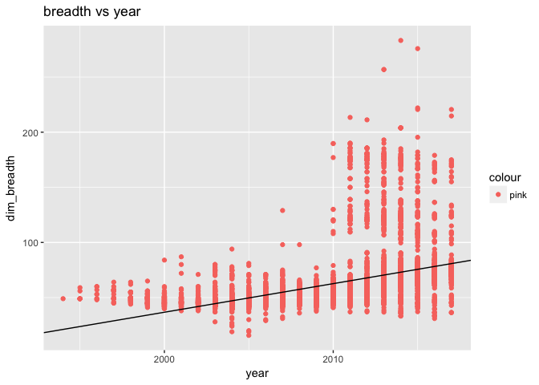

```r
p = ggplot(data = mobile, aes(x = year, y = dim_breadth,color = "pink"))
coef = coef(lm(dim_breadth ~ year, data = mobile))
p + geom_point() + geom_abline(intercept = coef[1], slope = coef[2])+
  ggtitle("breadth vs year")
```

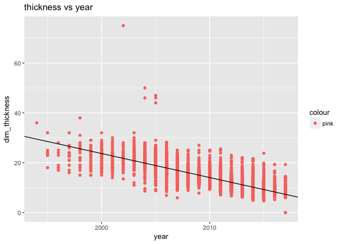

```r
p = ggplot(data = mobile, aes(x = year, y = dim_thickness,color = "pink"))
coef = coef(lm(dim_thickness ~ year, data = mobile))
p + geom_point() + geom_abline(intercept = coef[1], slope = coef[2])+
  ggtitle("thickness vs year")
```

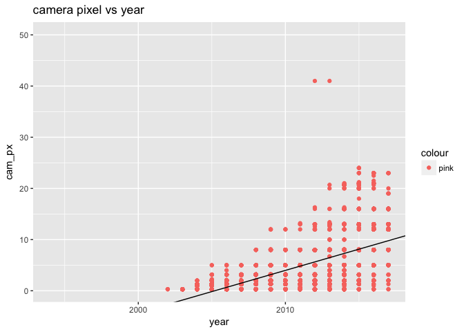

```r
p = ggplot(data = mobile, aes(x = year, y = cam_px,color = "pink"))
coef = coef(lm(cam_px ~ year, data = mobile))
p + geom_point() + geom_abline(intercept = coef[1], slope = coef[2])+
  ggtitle("camera pixel vs year")
```

۳. نمودار ستونی متوسط قیمت گوشی بر حسب تعداد سیم کارت و دسترسی به LTE را رسم نمایید.

ابتدا داده ها را برحسب تعداد سیمکارت گروه بندی کرده و سپس در هر گروه میانگین قیمت را حساب میکنیم. نمودا ستونی میانگین قیمت بر اساس تعداد سیمکارت ها را میکشیم و درصد به داشتن و نداشتن LTE را با کمک fill روی هر ستون نشان میدهیم.

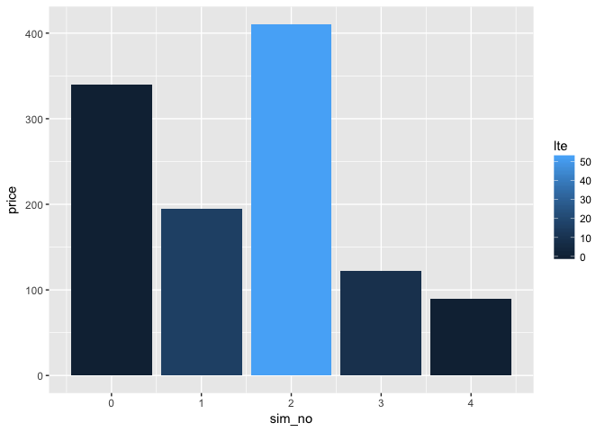

```r
#method 1
mobile %>% group_by(sim_no) %>% summarise(price=mean(price,na.rm=T),lteyes=sum(LTE=="Yes"),lteno=sum(LTE=="No")) %>% mutate(lte=round(100*lteyes/lteno))->stat

p = ggplot(stat, aes(x=sim_no,y=price))
p + geom_bar(stat ="identity",aes(fill=lte))
```

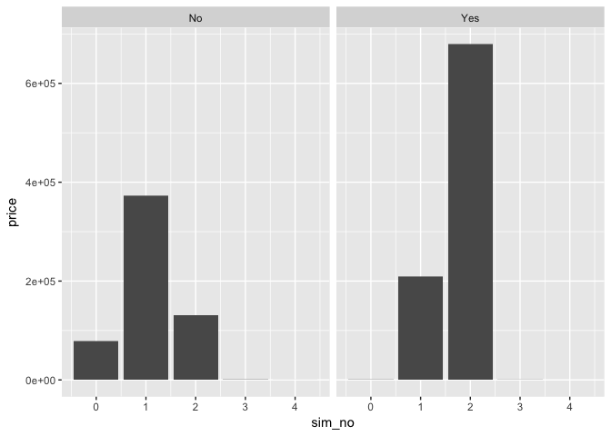

```r
#method 2
mobile %>%select(price,sim_no,LTE) %>% group_by(sim_no) %>% arrange(desc(sim_no))->data
ggplot(data=data,aes(x=sim_no,y=price))+geom_bar(stat="identity")+facet_wrap(~LTE)
```

۴. نمودار جعبه ایی ضحامت گوشی هایی که در سال ۲۰۱۷ معرفی شده اند را برحسب اینکه کمیت جک هدفون رسم نمایید

ابتدا داده ها را فیلتر کردیم تا فقط گوشی هایی که در سال ۲۰۱۷ تولید شدند را در نظر بگیریم. مفهرم نمودار جعبه ای کشیده شده در پایین این است که ۰.۲۵ داده در چارک پایین و۰.۲۵ داده در چارک بالا و نصف داده در جعبه قرار دارد.

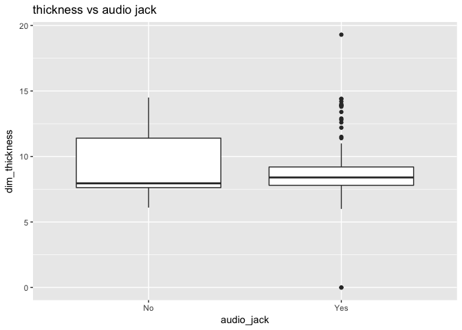

```r
case=mobile[which(mobile$year==2017),]
p = ggplot(case, aes(audio_jack,dim_thickness))+ggtitle("thickness vs audio jack")
p + geom_boxplot()
```

۵. مفهوم ppi را در گوشی های موبایل محاسبه و هیستوگرام آن را رسم نمایید. همچنین نمودار سالانه متوسط این کمیت را بکشید. کدام گوشی بیشترین ppi را دارد؟

با فرض اینکه صفحه نمایش بر حسب اینچ است نمودار هیستوگرام زیر را داریم

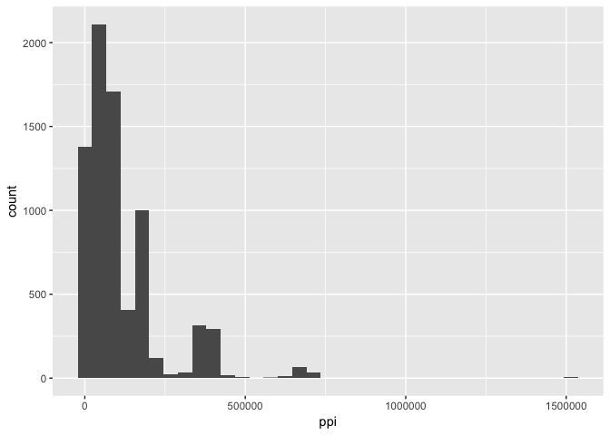

```r
pixel=(mobile$px_col)*(mobile$px_row)
inch=mobile$display_size
ppi=pixel/inch
#print(ppi)
ggplot(data = mobile,aes(x = ppi)) +geom_histogram(bins = 35)
```

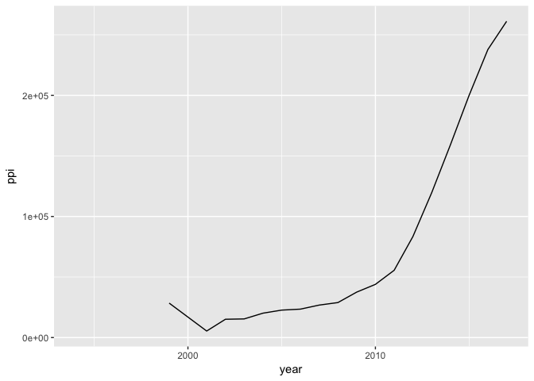

```r
mobile %>%
  group_by(year) %>%
  summarise(ppi=mean((px_row*px_col)/(display_size),na.rm=T)) ->stat

p = ggplot(data = stat,aes(x = year,y = ppi))
p + geom_line()
```

```r
cat("device with max ppi:",mobile$device[which.max((mobile$px_row*mobile$px_col)/(mobile$display_size))])
```

```
## device with max ppi: Xperia XZ Premium
```

۶. در گذشته به بعضی از مدل های گوشی نوکیا **گوشکوب** گفته می شد. سعی کنید برای این مفهوم کمیتی مناسب تعریف کنید . ده گوشکوب برتر را پیدا کرده و نمودار گوشکوبیت آن را رسم نمایید.

ابتدا داده را فیلتر میکنیم تا فقط گوشی های نوکیا را بررسی کنیم .

در زیر یک تعریف از گوشتکوبیت به عنوان ضخامت نسبت به سطح گوشی و نمودار های حاصل از آن را میبینیم . .۱۰ تا گوشکوب ترین گوشی ها در شکل نمایش داده شده است نتایج بدست آمده مربوط به سالهای ۲۰۰۳-۲۰۰۴ میباشد که منطقی است .

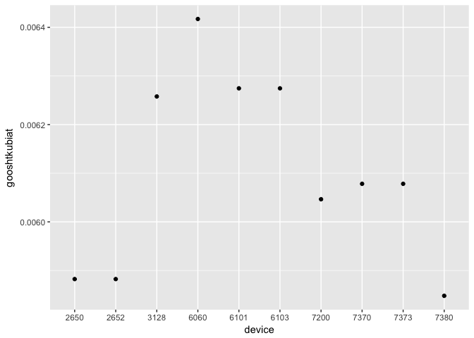

```r
# gooshtkub = thickness/length*breadth  kam bashad
case=mobile %>% filter(company=="Nokia")
gooshtkubiat=case$dim_thickness/(case$dim_length*case$dim_breadth)


library(dplyr)
case %>%
  group_by(device) %>%
  summarise(gooshtkubiat=dim_thickness/(dim_length*dim_breadth),year=year) %>% arrange(desc(gooshtkubiat))  ->stat




stat2=stat[1:10,]
p = ggplot(data = stat2,aes(x = device,y = gooshtkubiat))
p +geom_point()
```

۷. آیا تلفن همراهی وجود دارد که در آب غرق نشود؟ اگر جواب بله هست تمام گوشی های که این خاصیت را دارند بیابید. با کشیدن یک نمودار به این سوال پاسخ دهید.

چگالی تلفن های همراه را بدست آورده و آنهایی که چگالی آنها کوچکتر از ۱ هست و در نتیجه در آب غرق نمیشوند را نشان میدهیم تعداد تلفن ها ۱۰۱۴ تا و خیلی زیاد است و اسامی هم طولانی پس ما هرچقدر کوچک کنیم باز هم یا مشخص نمیشود یا تلاقی میکند پس قسمت قسمت نمودار داده را رسم میکنیم که در زیر میبینیم.

نام موبایل ها با چگالی کمتر از یک در فاینال ذخیره شده.

```r
mobile$density=1000*(mobile$weight/(mobile$dim_breadth*mobile$dim_thickness*mobile$dim_length))

final=mobile %>% filter(density<1)
dim(final)[1]
```

```
## [1] 1014
```

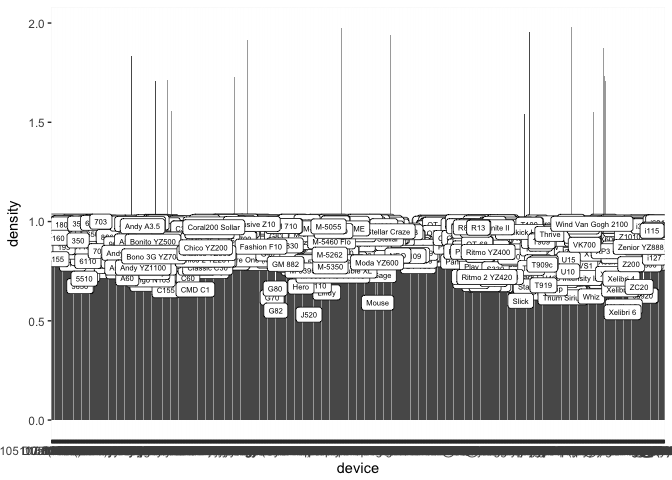

```r
ggplot(data=final,aes(x=device,y=density))+geom_bar(stat="identity",aes(x=device,y=density))+geom_label(aes(label=device),size=2)
```

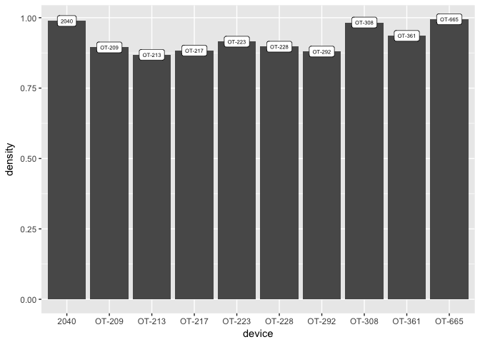

```r
finaldevice=final$device

# sample !!!
ggplot(data=final[1:10,],aes(x=device,y=density))+geom_bar(stat="identity",aes(x=device,y=density))+geom_label(aes(label=device),size=2)
```

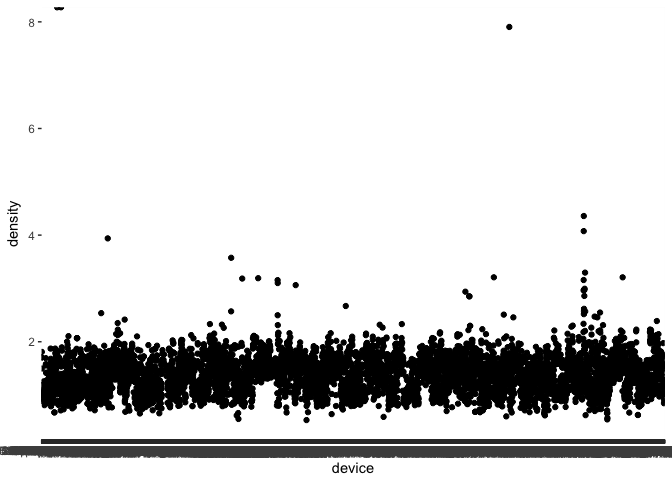

```r
p = ggplot(data = mobile)
p + geom_point(aes(x = device,y = density))
```

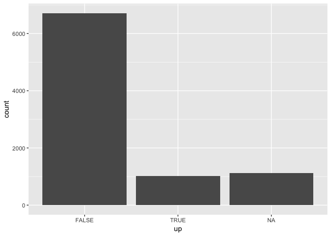

```r
#geombar of phones that do not sink in water
stat=mobile %>% select(device,density) %>% mutate(up=(density<1))
p = ggplot(data = stat)
p + geom_bar(aes(x=up))
```

من شک داشتم که پراکنش فارسی عه تابع توزیع است یا جیوم پوینت پس هر دو را کشیدم.

۸. نمودار پراکنش حجم ذخیره سازی باطری و وزن را رسم نمایید. میزان همبستگی بین این دو کمیت را محاسبه کنید.

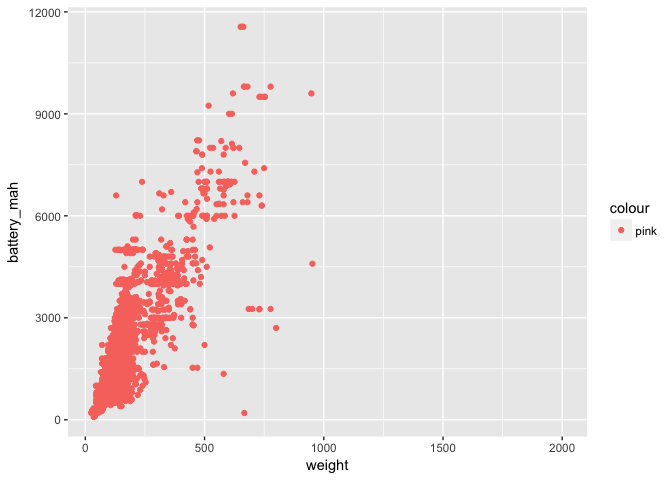

```r
#method 1

p = ggplot(mobile) +geom_point( aes(x = weight, y = battery_mah,color="pink"))
p
```

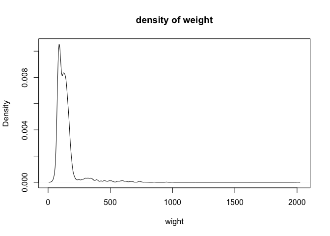

```r
#************************************************************************************************************
plot(density(mobile$weight,na.rm=T),xlab = "wight",main = "density of weight")
```

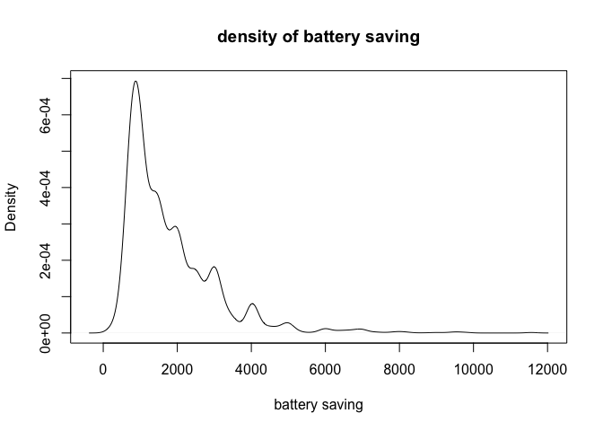

```r
plot(density(mobile$battery_mah,na.rm=T),xlab = "battery saving",main = "density of battery saving")
```

```r
#we calculated corr using 3 methods
cor(mobile$battery_mah, mobile$weight,use = "pairwise.complete.obs", method = c("pearson"))
```

```
## [1] 0.8086273
```

```r
cor(mobile$battery_mah, mobile$weight,use = "pairwise.complete.obs", method = c("kendall"))
```

```
## [1] 0.6422654
```

```r
cor(mobile$battery_mah, mobile$weight,use = "pairwise.complete.obs", method = c( "spearman"))
```

```
## [1] 0.8185562
```

```r
cor(mobile$battery_mah, mobile$weight,use = "complete.obs", method = c("pearson"))
```

```
## [1] 0.8086273
```

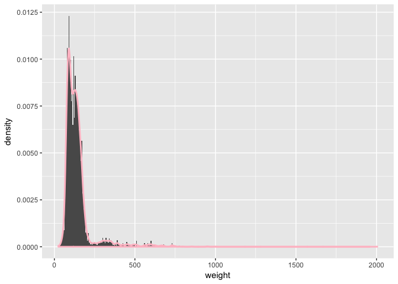

```r
#method 2
p = ggplot(mobile, aes(x = weight))
p + geom_histogram(binwidth = 5,aes(y = ..density..)) + geom_density(color = "pink",size = 1)
```

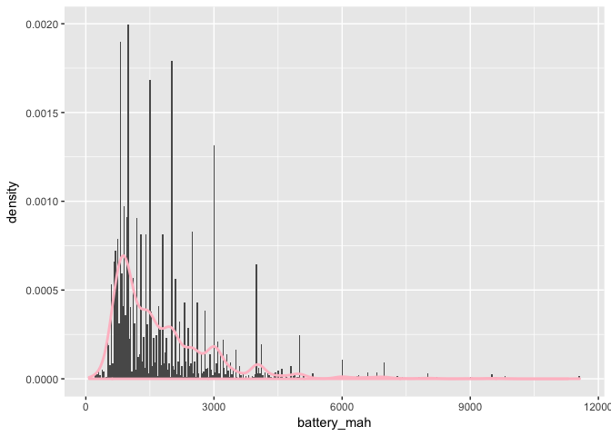

```r
p = ggplot(mobile, aes(x =battery_mah))
p +geom_histogram(binwidth = 30,aes(y = ..density..)) + geom_density(color = "pink",size = 1)
```

۹. قیمت پرچمداران یک برند خاص مثلا سامسونگ را بیابید و نمودار قیمت زمان و نام مدل را رسم نمایید.

```r
mobile %>% filter(company=="Samsung")->data
data %>% select(year,device,price)->stat
stat %>% group_by(year) %>% summarise(flagprice=max(price,na.rm = T)) ->stat2
```

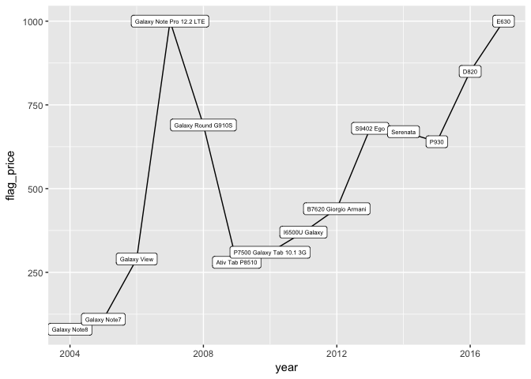

```r
stat3=stat2[8:21,]
stat4=cbind(stat3,device=c("Galaxy Note8","Galaxy Note7","Galaxy View","Galaxy Note Pro 12.2 LTE","Galaxy Round G910S","Ativ Tab P8510","P7500 Galaxy Tab 10.1 3G","I6500U Galaxy","B7620 Giorgio Armani","S9402 Ego","Serenata","P930","D820","E630"))


p = ggplot(stat3,aes(label=(stat4$device)))+geom_line(aes(x = stat3$year, y = stat3$flagprice))+geom_point( aes(x = stat3$year, y = stat3$flagprice))+xlab('year')+ylab('flag_price')+
  geom_label(aes(x = stat3$year, y = stat3$flagprice),size=2)
p
```

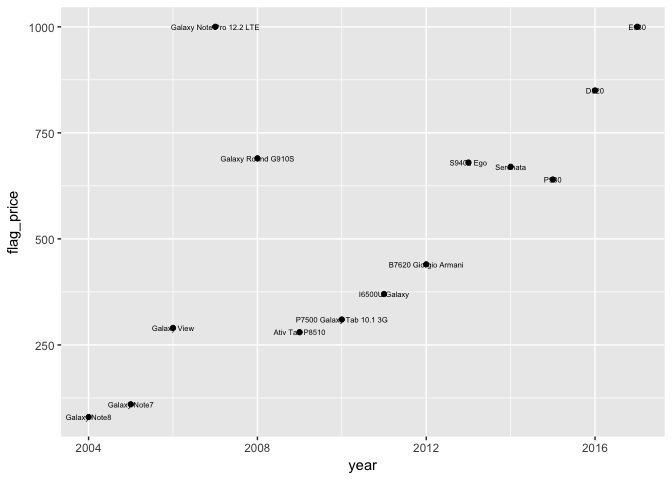

```r
p = ggplot(stat3,aes(label=(stat4$device)))+geom_point( aes(x = stat3$year, y = stat3$flagprice))+xlab('year')+ylab('flag_price')+
  geom_text(aes(x = stat3$year, y = stat3$flagprice),size=2)

p
```

۱۰. سه نمودار جالب رسم کنید و توضیح دهید چرا از نظر شما جالب است؟

Q1

روند وجود یا عدم وجود رادیو را در سال های مختلف بررسی میکنیم تا ببینیم آیا رادیو در حال حذف است یا نه؟(میبینیم که روند بر خلاف انتظار ما به شدت صعودی بوده ولی در سال های اخیر کمی نرول داشته پس با قطعیت نمیتوانیم روند را پیش بینی کنیم.

Q2

همبستگی ای بین خاصیت LTE و ضخامت گوشی میخاستم پیدا کنم که طبق انتظار من گوشی هایی که ال تی ای دارند ضخامت کمتری دارند. مقصود من بررسی نیاز فناوری ال تی ای در گوشی به ضخامت کم بود اما این نمودار فریب دهنده است چرا که کمیت وابسته ی سومی وجود دارد (سال !) یعنی شاید توجیه نمودار به این صورت است که با پیشرفت سال ضخامت گوشی ها کم شده و مستقلا فناوری ال تی ای هم پیشرفت میکند پس این سوال مناسبی نیست

Q3 در این نمودار تعداد گوشی ها بر اساس سال و فناوری ال تی ای نشان داده شده است. این نمودار به نحو مناسب و روشنی فرایند رشد فناوری ال تی ای را بر حسب سال و نرخ رشد نشان میدهد. حتی میتوان متوجه شد کی نخستین بار فناوری ال تی ای به وجود آمد.

Q4

در نمودار چهارم میخاستم برندی را پیدا کنم که بیشترین رنج مشتری را دارد یعنی رنج قیمت گوشی های آن بسیار متنوع است . در واقع این معیار به نحوی محبوبیت عمومی گوشی را نشان میدهد و این نکته ی جالب توجهی است:) البته چون قیمت گوشی ها در طول زمان تغییر کرده فقط از گوشی های ۲۰۱۶-۲۰۱۷ استفاده کردم.

Q5

در نمودار شماره پنچ تصمیم گرفتم شرکتی را پیدا کنم که بیشترین نرخ رشد قیمت را دارد.

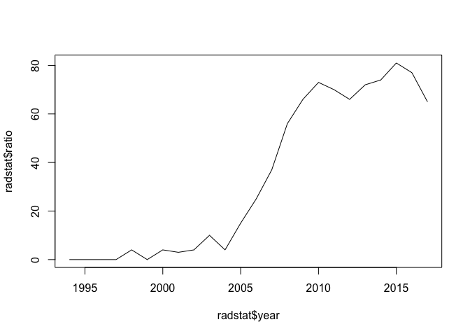

```r
#Q1
# radio ro be engheraz ya na?!
library(dplyr)
mobile %>% group_by(year) %>%
  summarise(count=n(),radio=sum(radio=="Yes")) ->radstat
View(radstat)

radstat$ratio=round(100*radstat$radio/radstat$count,0)
View(radstat)
plot(radstat$year,radstat$ratio,pch=16,type="l")
```

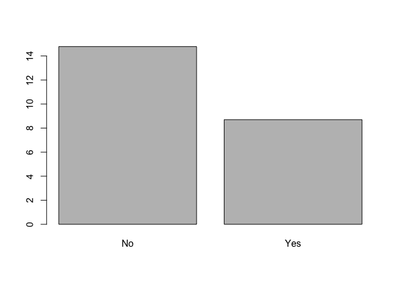

```r
#Q2 LTE and thickness
mobile %>% group_by(LTE) %>% summarise(av=mean(dim_thickness,na.rm=T))->stat
barplot(stat$av,names.arg = c("No","Yes"))
```

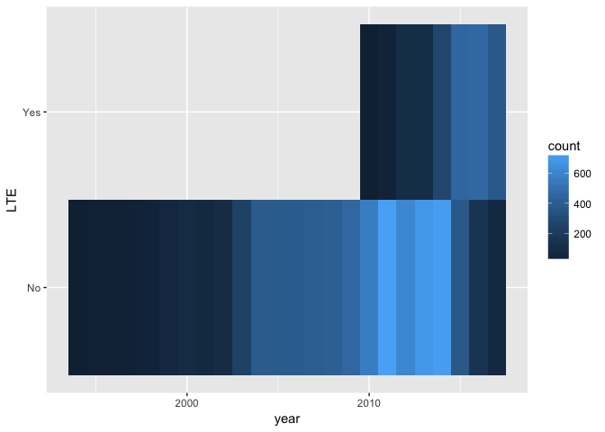

```r
#Q3
mobile %>% group_by(year,LTE) %>% summarise(count = n()) -> mob_count
ggplot(mob_count, aes(x =  year, y =LTE,fill = count)) + geom_tile()
```

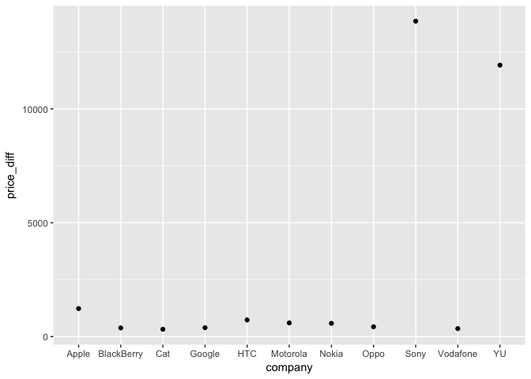

```r
#Q4
#poor and rich!

mobile %>% filter(year>2015 )->stat3
stat3 %>% group_by(company) %>% summarise(price_diff=(max(price)-min(price))) %>% arrange(desc(price_diff))->stat
stat[1:11,]->stat2

p = ggplot(stat2) +
  geom_point( aes(x =company, y = price_diff))
p
```

```r
print("Q4 => sony has the widest price range")
```

```
## [1] "Q4 => sony has the widest price range"
```

```r
mobile %>% filter(company=="Sony" & year>2015)->stat4
cat("Q4:the most expensive phone: ",stat4$device[which.max(stat4$price)])
```

```
## Q4:the most expensive phone:  Xperia R1 (Plus)
```

```r
print("\n")
```

```
## [1] "\n"
```

```r
cat("cheapest phone:", stat4$device[which.min(stat4$price)])
```

```
## cheapest phone: Xperia E5
```

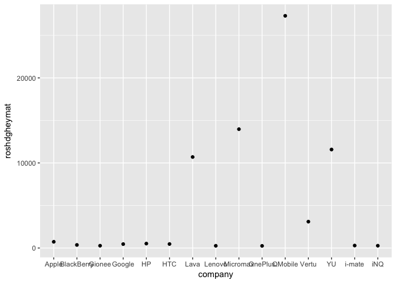

```r
#Q5
mobile %>% group_by(company) %>% summarise(roshdgheymat=price[which.max(year)]-price[which.min(year)]) %>% arrange(desc(roshdgheymat))->stat5
stat6=stat5[1:15,]

p = ggplot(stat6) +
  geom_point( aes(x = company, y = roshdgheymat))
p
```

```r
print("\n")
```

```
## [1] "\n"
```

```r
cat("Q5:",stat6$company[which.max(stat6$roshdgheymat)])
```

```
## Q5: QMobile
```

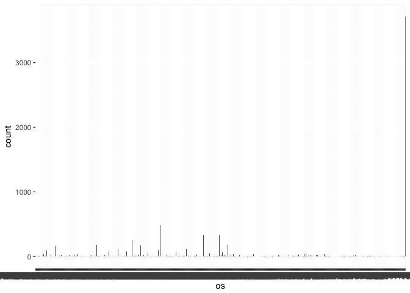

```r
#2
mobile %>% group_by(os) %>% summarise(count=n(),) %>% arrange(desc(count)) -> production
p = ggplot(production, aes(x=os,y=count))
p + geom_bar(stat ="identity")
```

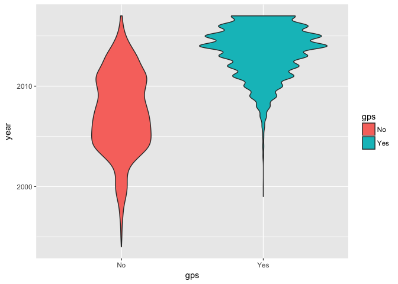

```r
#3

filtered = mobile
p = ggplot(mobile, aes(gps, year))
p + geom_violin(aes(fill = gps))
```